# Taller Análisis Exporatorio de Datos

Luis Eduardo Diaz Castro y Andrés Hernandez Acosta

22 de abril de 2019

## ANALISIS DE VIOLENCIA SEXUAL EN COLOMBIA EN EL 2017

Para ejecutar los codigos se deben descargar de el siguiente link https://github.com/luisdiaz1983/ANALISIS-EXPLORATORIO-DE-DATOS , los archivos mencionados posteriormente: 1- dane.csv 2- Delitos_sexuales_2017.csv 3- gadm36_COL_1.shp, este último requiere descargar una carpeta comprimida y se debe importar desde la misma carpeta.

```r
setwd("C:/Users/Luis Eduardo Diaz/Documents/MAESTRIA/ANALISIS EXPLORATORIO DE DATOS/CLASE 4")

dane <- read_delim("dane.csv", ";", escape_double = FALSE, col_types = cols(MPIO = col_character()), locale = locale(encoding = "ISO-8859-1",asciify = TRUE), trim_ws = TRUE)
d_sex <- read_csv("Delitos_sexuales_2017.csv")
```

```r
ohsCol2 <- shapefile("C:/Users/Luis Eduardo Diaz/Documents/MAESTRIA/ANALISIS EXPLORATORIO DE DATOS/CLASE 4/gadm36_COL_shp/gadm36_COL_1.shp") #se usa para crear mapa de delitos
```

Verificamos que esten bien cargados los dataframes, a continuación verificamos el dataframe “d_sex”

```r
summary(d_sex)
dim(d_sex)
head(d_sex)
tail(d_sex)
sapply(d_sex,class)
```

Igual con el dataframe “dane”

```r
summary(dane)
dim(dane)
head(dane)
tail(dane)
sapply(dane,class)
```

Una vez realizado esto procedemos a verificar Missing Values “NA” y “-”

```r
sapply(d_sex, function(x) sum(is.na(x)))
```

```
##              Fecha       Departamento          Municipio
##                  0                  0                  0
##             DELITO                Día               Hora
##                  0                  0                  0
##             Barrio               Zona     Clase de sitio
##                  0                  0                  0
##      Arma empleada      Móvil Agresor      Móvil Victima
##                  0                  0                  0
##               Edad               Sexo       Estado civil
##                226                  0                  0
## País de nacimiento  Clase de empleado          Profesión
##                  0                  0                  0
##        Escolaridad        Código DANE           Cantidad
##                  0                  1                  0
```

```r
sapply(d_sex, function(x){ length(which(x == "-"))})
```

```
##              Fecha       Departamento          Municipio
##                  0                  0                  1
##             DELITO                Día               Hora
##                  0                  0                  0
##             Barrio               Zona     Clase de sitio
##                  1                  0                  4
##      Arma empleada      Móvil Agresor      Móvil Victima
##                455                 46                 57
##               Edad               Sexo       Estado civil
##                  0                 30                119
## País de nacimiento  Clase de empleado          Profesión
##               8773                 30              28828
##        Escolaridad        Código DANE           Cantidad
##                157                  0                  0
```

# Operaciones con Variables del dataframe d_sex

Debido a que tenemos variables con mayusculas, tíldes, formato diferente de fecha y hora, se procede a realizar los ajustes necesarios.

Primero haremos que los nombres de las variables esten en minúscula para disminuir la probabilidad de cometer errores con las mismas:

```r
colnames(d_sex)<-tolower(make.names(chartr('áéíóúñ','aeioun',colnames(d_sex))))
colnames(d_sex)<-tolower(make.names(chartr('áéíóúñ','aeioun',colnames(d_sex))))
colnames(d_sex)<-chartr('.','_',colnames(d_sex))
```

Para poder trabajar con el gráfico del mapa de Colombia se deben cambiar los registros de departamento y municipio a minúsculas y sin tíldes de los dataframes “d_sex”" y “dane”, como se muestra a continuación:

```r
d_sex$departamento <- tolower(chartr('áéíóúñ','aeioun',d_sex$departamento))
d_sex$departamento <- tolower(chartr('áéíóúñ','aeioun',d_sex$departamento))
d_sex$municipio <- tolower(chartr('áéíóúñ','aeioun',d_sex$municipio))
d_sex$municipio <- tolower(chartr('áéíóúñ','aeioun',d_sex$municipio))
dane$DPNOM <- tolower(chartr('áéíóúñ','aeioun',dane$DPNOM))
dane$DPNOM <- tolower(chartr('áéíóúñ','aeioun',dane$DPNOM))
dane$MPIO <- tolower(chartr('áéíóúñ','aeioun',dane$MPIO))
dane$MPIO <- tolower(chartr('áéíóúñ','aeioun',dane$MPIO))
```

También se realizan los ajustes de tipo Fecha y se agrega factor a una nueva varianble “h” con formato 24 horas:

```r
d_sex$fecha <-as.Date(d_sex$fecha,format="%m/%d/%Y")
d_sex$h <-hour(mdy_hms(d_sex$hora))
d_sex$h<-as.factor(d_sex$h)
```

# Codificación de variable delito

Esta variable contiene niveles con demasiados caracteres, asi se decide recodificar los niveles de la variable, para poder analizarla de mejor manera:

```r
d_sex$delito<-as.factor(d_sex$delito)
levels(d_sex$delito)
```

```
##  [1] "ARTÍCULO 205. ACCESO CARNAL VIOLENTO"
##  [2] "ARTÍCULO 206. ACTO SEXUAL VIOLENTO"
##  [3] "ARTÍCULO 207. ACCESO CARNAL O ACTO SEXUAL EN PERSONA PUESTA EN INCAPACIDAD DE RESISTIR"
##  [4] "ARTÍCULO 208. ACCESO CARNAL ABUSIVO CON MENOR DE 14 AÑOS"
##  [5] "ARTÍCULO 209. ACTOS SEXUALES CON MENOR DE 14 AÑOS"
##  [6] "ARTÍCULO 210 A. ACOSO SEXUAL"
##  [7] "ARTÍCULO 210. ACCESO CARNAL O ACTO SEXUAL ABUSIVO CON INCAPAZ DE RESISTIR"
##  [8] "ARTÍCULO 211. ACCESO CARNAL ABUSIVO CON MENOR DE 14 AÑOS (CIRCUNSTANCIAS AGRAVACIÓN)"
##  [9] "ARTÍCULO 211. ACCESO CARNAL O ACTO SEXUAL ABUSIVO CON INCAPAZ DE RESISTIR (CIRCUNSTANCIAS AGRAVACIÓN"
## [10] "ARTÍCULO 211. ACCESO CARNAL O ACTO SEXUAL EN PERSONA PUESTA EN INCAPACIDAD DE RESISTIR  (CIRCUNSTANC"
## [11] "ARTÍCULO 211. ACCESO CARNAL VIOLENTO (CIRCUNSTANCIAS AGRAVACIÓN)"
## [12] "ARTÍCULO 211. ACTO SEXUAL VIOLENTO (CIRCUNSTANCIAS DE AGRAVACIÓN)"
## [13] "ARTÍCULO 211. ACTOS SEXUALES CON MENOR DE 14 AÑOS (CIRCUNSTANCIAS DE AGRAVACIÓN)"
## [14] "ARTÍCULO 213 A. PROXENETISMO CON MENOR DE EDAD"
## [15] "ARTÍCULO 213. INDUCCIÓN A LA PROSTITUCIÓN"
## [16] "ARTÍCULO 214. CONSTREÑIMIENTO A LA PROSTITUCIÓN"
## [17] "ARTÍCULO 216. CONSTREÑIMIENTO A LA PROSTITUCIÓN (CIRCUNSTANCIAS AGRAVACIÓN)"
## [18] "ARTÍCULO 217 A. DEMANDA DE EXPLOTACION SEXUAL COMERCIAL DE PERSONA MENOR DE 18 AÑOS DE EDAD"
## [19] "ARTÍCULO 217. ESTÍMULO A LA PROSTITUCIÓN DE MENORES"
## [20] "ARTÍCULO 218. PORNOGRAFÍA CON MENORES"
## [21] "ARTÍCULO 219 A. UTILIZACIÓN O FACILITACIÓN DE MEDIOS DE COMUNICACIÓN PARA OFRECER SERVICIOS SEXUALES DE MENORES"
## [22] "ARTÍCULO 219 B. OMISIÓN DE DENUNCIA"
```

```r
d_sex$delitocod<-d_sex$delito
levels(d_sex$delitocod) <- c("205","206","207","208","209","210","2101","211","2111","2112","2113","2114","2115","213","2131","214","216","217","2171","218","219","2191")
View(d_sex$delito)
View(d_sex$delitocod)
```

# Tratamiento de Missing Values variable “edad”

Debido a las inconsistencias entre las edades y el delito se utiliza la siguiente linea para realizar la identificacion de datos mal etiquetados, se procede a realizar ajustes de la siguiente manera:

Primero se deben encontrar los valores de la media de la edad para ser reemplazados en valores “-” asociados a: , menores a 18 años y mayores a 18.

```r
View(table(d_sex$edad<=14, d_sex$delito, dnn=c("edad", "delito")))
#View(filter(d_sex,is.na(edad)))
```

Delitos en menores de 14 años

```r
edadmenor14<-d_sex %>% dplyr::select(edad,delitocod)%>%filter(edad<=14)
round(mean(edadmenor14$edad),0)
```

```
## [1] 10
```

Delitos en menores de 18 años

```r
edadmenor18<-d_sex %>% dplyr::select(edad,delitocod)%>%filter(edad<=18)
round(mean(edadmenor18$edad),0)
```

```
## [1] 12
```

Delitos en mayores de 18 años

```r
edadmayor18<-d_sex %>% dplyr::select(edad,delitocod)%>%filter(edad>18)
round(mean(edadmayor18$edad),0)
```

```
## [1] 31
```

Para los valores NA de edad se utiliza el delito como variable para determinar la edad, para menores de 14 el valor identificado es de 10

```r
d_sex2<- d_sex %>%mutate(edad = ifelse((is.na(edad)) & (delitocod=="208" | delitocod=="209"| delitocod=="211"| delitocod=="2115") , round(mean(edadmenor14$edad),0), edad))
View(d_sex2 %>% dplyr::select(edad,delitocod)%>%filter(delitocod=="208" | delitocod=="209"| delitocod=="211"| delitocod=="2115"))
```

Para los valores NA de edad se utiliza el delito como variable para determinar la edad, para menores de 18 el valor identificado es de 12

```r
d_sex2<- d_sex2 %>%mutate(edad = ifelse((is.na(edad)) & (delitocod=="217" | delitocod=="2171"| delitocod=="218"| delitocod=="219"| delitocod=="213") , round(mean(edadmenor18$edad),0), edad))
View(d_sex2 %>% dplyr::select(edad,delitocod)%>%filter(delitocod=="217" | delitocod=="2171"| delitocod=="218"| delitocod=="219"| delitocod=="213"))
```

Para los valores NA de edad se utiliza el delito como variable para determinar la edad, para mayores de 18 el valor identificado es de 31

```r
d_sex2<- d_sex2 %>%mutate(edad = ifelse((is.na(edad)) , round(mean(edadmayor18$edad),0), edad))
View(d_sex2 %>% dplyr::select(edad,delitocod))
```

Para los valores NA de edad se utiliza el delito como variable para determinar la edad, para menores de 18 el valor identificado es de 12:

```r
d_sex2<- d_sex2 %>%mutate(edad = ifelse((is.na(edad)) & (delitocod=="217" | delitocod=="2171"| delitocod=="218"| delitocod=="219") , round(mean(edadmenor18$edad),0), edad))
View(d_sex2 %>% dplyr::select(edad,delitocod)%>%filter(delitocod=="217" | delitocod=="2171"| delitocod=="218"| delitocod=="219"))

#View(filter(d_sex2,is.na(edad)))
```

# Otros Valores NA y Outliers

De acuerdo con lo observado anteriormente la variable codigo_dane presenta un missing value, este se elimina ya que no afeta el análisis.

```r
d_sex2 <- d_sex2[-which(is.na(d_sex$codigo_dane)),]
summary(d_sex2)
```

```
##      fecha            departamento        municipio
##  Min.   :2017-01-01   Length:29192       Length:29192
##  1st Qu.:2017-03-31   Class :character   Class :character
##  Median :2017-06-25   Mode  :character   Mode  :character
##  Mean   :2017-06-24
##  3rd Qu.:2017-09-16
##  Max.   :2017-12-31
##
##                                                                        delito
##  ARTÍCULO 209. ACTOS SEXUALES CON MENOR DE 14 AÑOS                        :11346
##  ARTÍCULO 208. ACCESO CARNAL ABUSIVO CON MENOR DE 14 AÑOS                 : 6613
##  ARTÍCULO 205. ACCESO CARNAL VIOLENTO                                     : 3811
##  ARTÍCULO 206. ACTO SEXUAL VIOLENTO                                       : 2810
##  ARTÍCULO 210 A. ACOSO SEXUAL                                             : 1630
##  ARTÍCULO 210. ACCESO CARNAL O ACTO SEXUAL ABUSIVO CON INCAPAZ DE RESISTIR: 1019
##  (Other)                                                                  : 1963
##      dia                hora              barrio
##  Length:29192       Length:29192       Length:29192
##  Class :character   Class :character   Class :character
##  Mode  :character   Mode  :character   Mode  :character
##
##
##
##
##      zona           clase_de_sitio     arma_empleada
##  Length:29192       Length:29192       Length:29192
##  Class :character   Class :character   Class :character
##  Mode  :character   Mode  :character   Mode  :character
##
##
##
##
##  movil_agresor      movil_victima           edad            sexo
##  Length:29192       Length:29192       Min.   :  0.00   Length:29192
##  Class :character   Class :character   1st Qu.: 10.00   Class :character
##  Mode  :character   Mode  :character   Median : 14.00   Mode  :character
##                                        Mean   : 15.44
##                                        3rd Qu.: 18.00
##                                        Max.   :111.00
##
```

[output cut: 9 more lines]

```
##  Length:29192       Length:29192       Min.   : 5001000   Min.   : 1.000
##  Class :character   Class :character   1st Qu.:11001000   1st Qu.: 1.000
##  Mode  :character   Mode  :character   Median :25290000   Median : 1.000
##                                        Mean   :36684074   Mean   : 1.044
##                                        3rd Qu.:68001000   3rd Qu.: 1.000
##                                        Max.   :99773000   Max.   :10.000
##
##        h           delitocod
##  0      :13734   209    :11346
##  8      : 1402   208    : 6613
##  10     : 1365   205    : 3811
##  15     : 1193   206    : 2810
##  16     : 1071   210    : 1630
##  18     :  888   2101   : 1019
##  (Other): 9539   (Other): 1963
```

Con la variable edad tambien pudimos observar que su valor mayor esta muy alejado de la media, por lo tanto se procede con la eliminación de este registro.

```r
max(d_sex2$edad)
```

```
## [1] 111
```

```r
d_sex2 <- d_sex2[-which(d_sex2$edad == max(d_sex2$edad)),]
```

# Ajuste de Registros mal Digitados o Categorizados

Se procede a realizar ajustes de los registros con errores de captura, de acuerdo al tipo de crimen y la edad del agredido

```r
d_sex3<- d_sex2
View(table(d_sex3$edad<=14, d_sex3$delitocod, dnn=c("edad", "delito")))

d_sex3$delitocod<-as.character(d_sex3$delitocod)
d_sex3<- d_sex3 %>%mutate(delitocod = ifelse((edad>14) & (delitocod=="208") ,205, delitocod))
d_sex3<- d_sex3 %>%mutate(delitocod = ifelse((edad>14) & (delitocod=="211") ,205, delitocod))
d_sex3<- d_sex3 %>%mutate(delitocod = ifelse((edad>14) & (delitocod=="2115") ,206, delitocod))
d_sex3<- d_sex3 %>%mutate(delitocod = ifelse((edad>18) & (delitocod=="213") ,2131, delitocod))
d_sex3<- d_sex3 %>%mutate(delitocod = ifelse((edad<18) & (delitocod=="2131") ,213, delitocod))
d_sex3<- d_sex3 %>%mutate(delitocod = ifelse((edad<18) & (delitocod=="214") ,213, delitocod))
d_sex3<- d_sex3 %>%mutate(delitocod = ifelse((edad>=18) & (delitocod=="2171") ,2131, delitocod))
d_sex3<- d_sex3 %>%mutate(delitocod = ifelse((edad>=18) & (delitocod=="217") ,2131, delitocod))
```

# Conversión de variables a factores:

Para regresar a la parametrización inicial de la variable delito se deben asignar nuevamente los niveles con la descripción completa del crimen:

```r
d_sex3$delitocod<-as.factor(d_sex3$delitocod)
levels(d_sex3$delitocod)
d_sex3$delito<-d_sex3$delitocod
levels(d_sex3$delito )<- c("ARTÍCULO 205. ACCESO CARNAL VIOLENTO",  "ARTÍCULO 206. ACTO SEXUAL VIOLENTO",   "ARTÍCULO 207. ACCESO CARNAL O ACTO SEXUAL EN PERSONA PUESTA EN INCAPACIDAD DE RESISTIR",   "ARTÍCULO 208. ACCESO CARNAL ABUSIVO CON MENOR DE 14 AÑOS", "ARTÍCULO 209. ACTOS SEXUALES CON MENOR DE 14 AÑOS",    "ARTÍCULO 210 A. ACOSO SEXUAL", "ARTÍCULO 210. ACCESO CARNAL O ACTO SEXUAL ABUSIVO CON INCAPAZ DE RESISTIR",    "ARTÍCULO 211. ACCESO CARNAL ABUSIVO CON MENOR DE 14 AÑOS (CIRCUNSTANCIAS AGRAVACIÓN)", "ARTÍCULO 211. ACCESO CARNAL O ACTO SEXUAL ABUSIVO CON INCAPAZ DE RESISTIR (CIRCUNSTANCIAS AGRAVACIÓN", "ARTÍCULO 211. ACCESO CARNAL O ACTO SEXUAL EN PERSONA PUESTA EN INCAPACIDAD DE RESISTIR  (CIRCUNSTANC", "ARTÍCULO 211. ACCESO CARNAL VIOLENTO (CIRCUNSTANCIAS AGRAVACIÓN)", "ARTÍCULO 211. ACTO SEXUAL VIOLENTO (CIRCUNSTANCIAS DE AGRAVACIÓN)",    "ARTÍCULO 211. ACTOS SEXUALES CON MENOR DE 14 AÑOS (CIRCUNSTANCIAS DE AGRAVACIÓN)", "ARTÍCULO 213 A. PROXENETISMO CON MENOR DE EDAD",   "ARTÍCULO 213. INDUCCIÓN A LA PROSTITUCIÓN",    "ARTÍCULO 214. CONSTREÑIMIENTO A LA PROSTITUCIÓN",  "ARTÍCULO 216. CONSTREÑIMIENTO A LA PROSTITUCIÓN (CIRCUNSTANCIAS AGRAVACIÓN)",  "ARTÍCULO 217 A. DEMANDA DE EXPLOTACION SEXUAL COMERCIAL DE PERSONA MENOR DE 18 AÑOS DE EDAD",  "ARTÍCULO 217. ESTÍMULO A LA PROSTITUCIÓN DE MENORES",  "ARTÍCULO 218. PORNOGRAFÍA CON MENORES","ARTÍCULO 219 A. UTILIZACIÓN O FACILITACIÓN DE MEDIOS DE COMUNICACIÓN PARA OFRECER SERVICIOS SEXUALES DE MENORES","ARTÍCULO 219 B. OMISIÓN DE DENUNCIA")
```

Luego procedemos a convertir las demas variables categóricas a factor:

```r
d_sex3$departamento<-as.factor(d_sex3$departamento)
levels(d_sex3$departamento)
d_sex3$municipio<-as.factor(d_sex3$municipio)
levels(d_sex3$municipio)
d_sex3$dia<-as.factor(d_sex3$dia)
levels(d_sex3$dia)
d_sex3$clase_de_sitio<-as.factor(d_sex3$clase_de_sitio)
levels(d_sex3$clase_de_sitio)
d_sex3$barrio<-as.factor(d_sex3$barrio)
levels(d_sex3$barrio)
d_sex3$arma_empleada<-as.factor(d_sex3$arma_empleada)
levels(d_sex3$arma_empleada)
d_sex3$movil_agresor<-as.factor(d_sex3$movil_agresor)
levels(d_sex3$movil_agresor)
d_sex3$movil_victima<-as.factor(d_sex3$movil_victima)
levels(d_sex3$movil_victima)
d_sex3$sexo<-as.factor(d_sex3$sexo)
levels(d_sex3$sexo)
d_sex3$estado_civil<-as.factor(d_sex3$estado_civil)
levels(d_sex3$estado_civil)
d_sex3$escolaridad<-as.factor(d_sex3$escolaridad)
levels(d_sex3$escolaridad)
d_sex3$profesion<-as.factor(d_sex3$profesion)
levels(d_sex3$profesion)
d_sex3$pais_de_nacimiento<-as.factor(d_sex3$pais_de_nacimiento)
levels(d_sex3$pais_de_nacimiento)
d_sex3$zona<-as.factor(d_sex3$zona)
levels(d_sex3$zona)
d_sex3$clase_de_empleado<-as.factor(d_sex3$clase_de_empleado)
levels(d_sex3$clase_de_empleado)
d_sex3$codigo_dane<-as.factor(d_sex3$codigo_dane)
levels(d_sex3$codigo_dane)
```

## ANÁLISIS GRÁFICO DE VARIABLES

## Análisis Univariado

Debido a que el dataframe principal contiene muchas variables categoricas se procede a realizar análisis gráfico de barras por frecuencia de las variables.

1 - Gráfica de Delitos Sexuales por Departamento

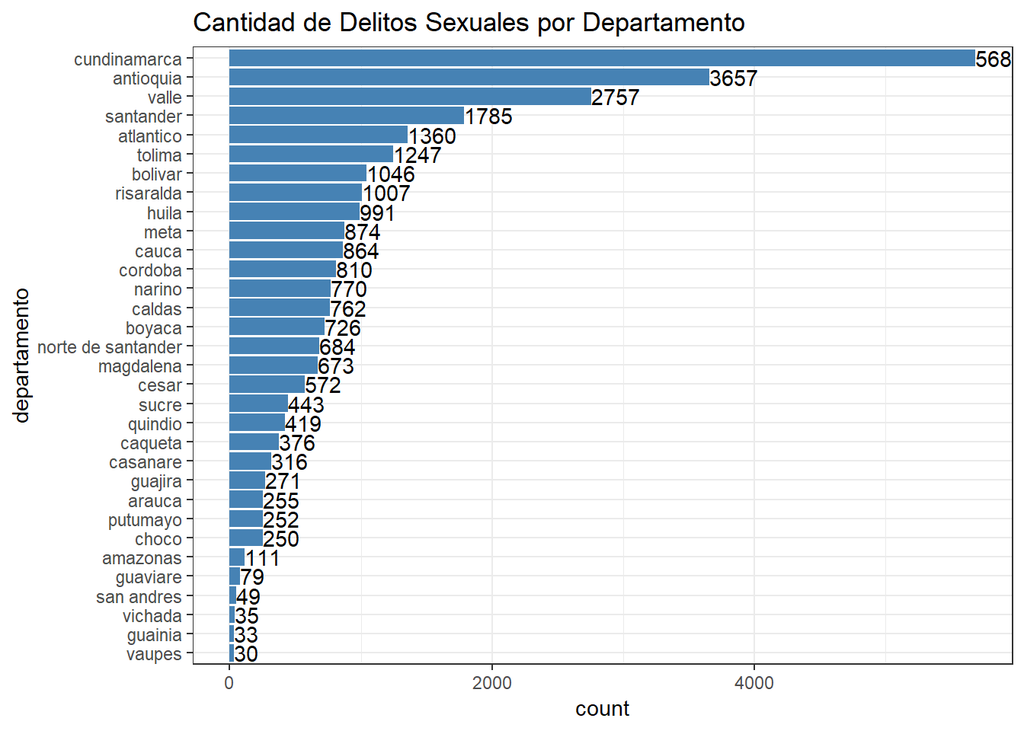

```r
dptosums<-table(d_sex3$departamento)
dpto <- as.data.frame(dptosums)
colnames(dpto) <- c("departamento", "count")

dpto <- transform(dpto, departamento=reorder(departamento, count))

ggplot(dpto) + geom_bar(aes(x=departamento, y=count), stat="identity", fill="steelblue") +
  geom_text(aes(x=departamento,  y=count, hjust= 0.0001, label=count)) + labs(title = "Cantidad de Delitos Sexuales por Departamento", fill = "") + coord_flip() + theme_bw() + theme(axis.text.y = element_text(size=(rel(1))))
```

2- Gráfica por Tipo de Ddelito

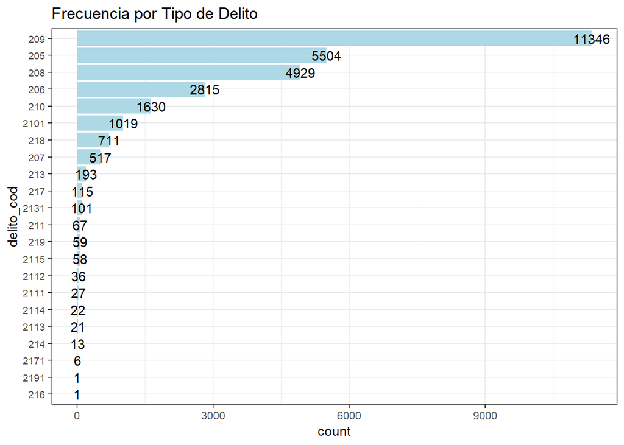

```r
crimesums <- table(d_sex3$delitocod)
crime <- as.data.frame(crimesums)
colnames(crime) <- c("delito_cod", "count")
crime <- transform(crime, delito_cod=reorder(delito_cod, count))

ggplot(crime) + geom_bar(aes(x=delito_cod, y=count), stat="identity", fill="lightblue") +
  geom_text(aes(x=delito_cod,  y=count, hjust= 0.5, label=count)) + labs(title = "Frecuencia por Tipo de Delito", fill = "") + coord_flip() + theme_bw() + theme(axis.text.y = element_text(size=(rel(0.9))))
```

3- Gráfica de delitos sexuales por zona

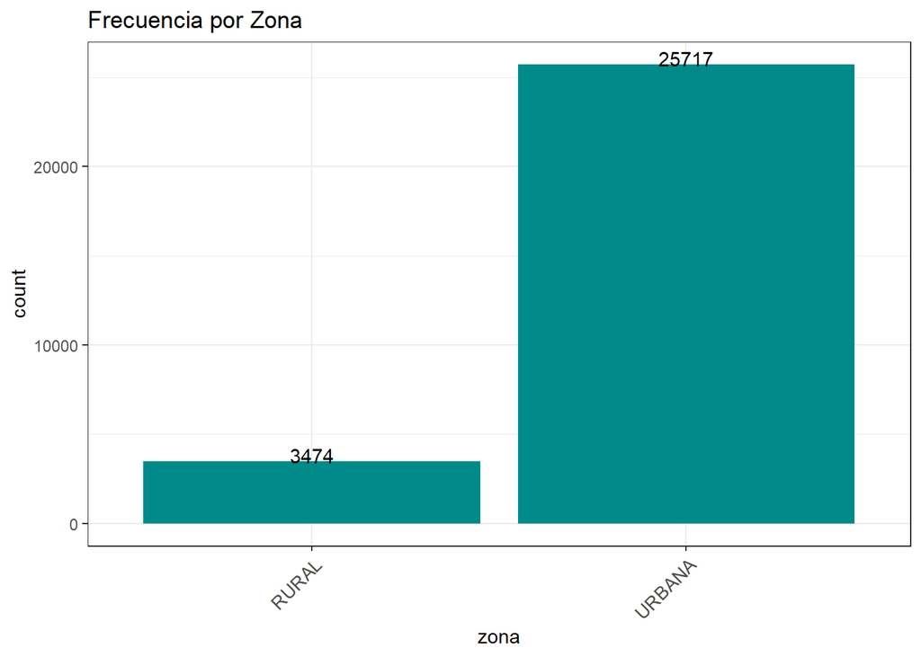

```r
zonesums <- table(d_sex3$zona)
zone <- as.data.frame(zonesums)
colnames(zone) <- c("zona", "count")
zone <- transform(zone, zona=reorder(zona, count))

ggplot(zone) + geom_bar(aes(x=zona, y=count), stat="identity", fill="cyan4") +
  geom_text(aes(x=zona,  y=count, vjust= 0.1, label=count)) + labs(title = "Frecuencia por Zona", fill = "") +
  theme_bw() +  theme(axis.text.x = element_text(size  = 10,angle = 45,hjust = 1,vjust = 1))
```

4- Gráfica de delitos sexuales por hora

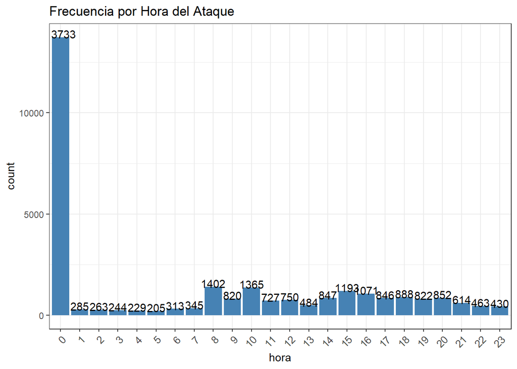

```r
Hoursums <- table(d_sex3$h)
Hour <- as.data.frame(Hoursums)
colnames(Hour) <- c("hora", "count")

ggplot(Hour) + geom_bar(aes(x=hora, y=count), stat="identity", fill="steelblue") +
  geom_text(aes(x=hora,  y=count, vjust= 0.1, label=count)) + labs(title = "Frecuencia por Hora del Ataque", fill = "") +
  theme_bw() +  theme(axis.text.x = element_text(size  = 10,angle = 45,hjust = 1,vjust = 1))
```

5- Tabla delitos sexuales por dia

Se toma en consideración una tabla de frecuencia de delitos por día y probabilidad de ocurrencia:

```r
table(d_sex3$dia)
```

```
##
##   Domingo    Jueves     Lunes    Martes Miércoles    Sábado   Viernes
##      3990      4204      4215      4437      4453      3511      4381
```

```r
prop.table(table(d_sex3$dia))
```

```
##
##   Domingo    Jueves     Lunes    Martes Miércoles    Sábado   Viernes
## 0.1366860 0.1440170 0.1443938 0.1519989 0.1525470 0.1202768 0.1500805
```

6- Histograma por arma empleada

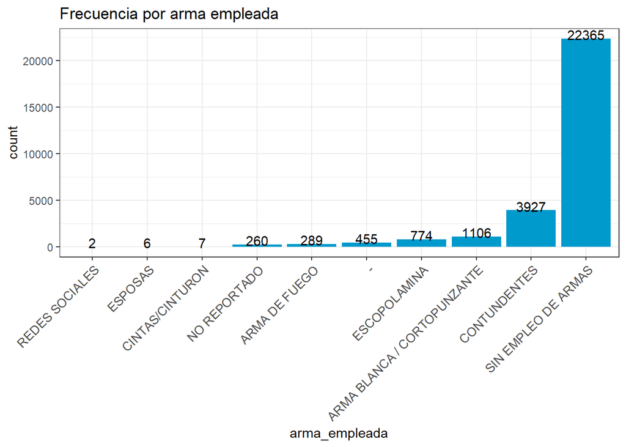

```r
weaponsums <- table(d_sex3$arma_empleada)
weapon <- as.data.frame(weaponsums)
colnames(weapon) <- c("arma_empleada", "count")
weapon <- transform(weapon, arma_empleada=reorder(arma_empleada, count))

ggplot(weapon) + geom_bar(aes(x=arma_empleada, y=count), stat="identity", fill="deepskyblue3") +
  geom_text(aes(x=arma_empleada,  y=count, vjust= 0.1, label=count)) + labs(title = "Frecuencia por arma empleada", fill = "") +
  theme_bw() +  theme(axis.text.x = element_text(size  = 10,angle = 45,hjust = 1,vjust = 1))
```

7- Proporción Sexo

```r
table(d_sex3$sexo)
```

```
##
##         -  FEMENINO MASCULINO
##        30     25307      3854
```

```r
prop.table(table(d_sex3$sexo))
```

```
##
##           -    FEMENINO   MASCULINO
## 0.001027714 0.866945291 0.132026995
```

Adicionalmente se considera agrupar la variable edad y realizar una tabla de frecuencias para evaluar los grupos de edad que son mas vulnerables a este tipo de delitos:

Cálculo de número de clases “k”

```r
#tabyl(d_sex3$edad, sort = TRUE)
#tab1(d_sex3$edad, sort.group = "decreasing", cum.percent = TRUE)
k <- (1 + 3.332*log(29191))
k
```

```
## [1] 35.25834
```

Cálculo de Rango de cada Clase “k”

```r
Amp <- max(d_sex3$edad)/k
Amp
```

```
## [1] 2.609311
```

A continuación se procede con la tabla y posterior gráfica:

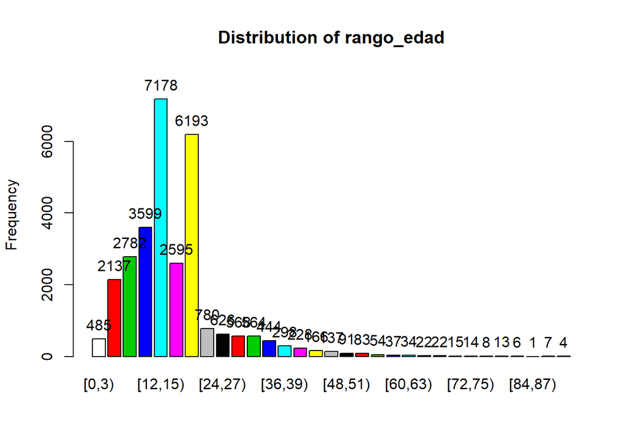

```
## rango_edad :
##         Frequency   %(NA+) cum.%(NA+)   %(NA-) cum.%(NA-)
## [0,3)         485      1.7        1.7      1.7        1.7
## [3,6)        2137      7.3        9.0      7.3        9.0
## [6,9)        2782      9.5       18.5      9.5       18.5
## [9,12)       3599     12.3       30.8     12.3       30.8
## [12,15)      7178     24.6       55.4     24.6       55.4
## [15,18)      2595      8.9       64.3      8.9       64.3
## [18,21)      6193     21.2       85.5     21.2       85.5
## [21,24)       780      2.7       88.2      2.7       88.2
## [24,27)       626      2.1       90.4      2.1       90.4
## [27,30)       568      1.9       92.3      1.9       92.3
## [30,33)       564      1.9       94.2      1.9       94.2
## [33,36)       444      1.5       95.8      1.5       95.8
## [36,39)       298      1.0       96.8      1.0       96.8
## [39,42)       228      0.8       97.6      0.8       97.6
## [42,45)       166      0.6       98.1      0.6       98.1
## [45,48)       137      0.5       98.6      0.5       98.6
## [48,51)        91      0.3       98.9      0.3       98.9
## [51,54)        83      0.3       99.2      0.3       99.2
## [54,57)        54      0.2       99.4      0.2       99.4
## [57,60)        37      0.1       99.5      0.1       99.5
## [60,63)        34      0.1       99.6      0.1       99.6
## [63,66)        22      0.1       99.7      0.1       99.7
## [66,69)        22      0.1       99.8      0.1       99.8
## [69,72)        15      0.1       99.8      0.1       99.8
## [72,75)        14      0.0       99.9      0.0       99.9
## [75,78)         8      0.0       99.9      0.0       99.9
## [78,81)        13      0.0       99.9      0.0      100.0
## [81,84)         6      0.0      100.0      0.0      100.0
## [84,87)         1      0.0      100.0      0.0      100.0
## [87,90]         7      0.0      100.0      0.0      100.0
## NA's            4      0.0      100.0      0.0      100.0
##   Total     29191    100.0      100.0    100.0      100.0
```

```r
attach(d_sex3)
breaks <- seq(from = min(edad), to = max(edad), by=3)
rango_edad <- cut(edad, breaks = breaks, right=FALSE, include.lowest = TRUE)
#cbind(table(rango_edad))
#tabyl(rango_edad, sort = FALSE)
tab1(rango_edad, sort.group = FALSE, cum.percent = TRUE)
```

```r
detach(d_sex3)
```

## Análisis Bivariado

En esta sección se pretende encontrar las relaciones entre varias variables:

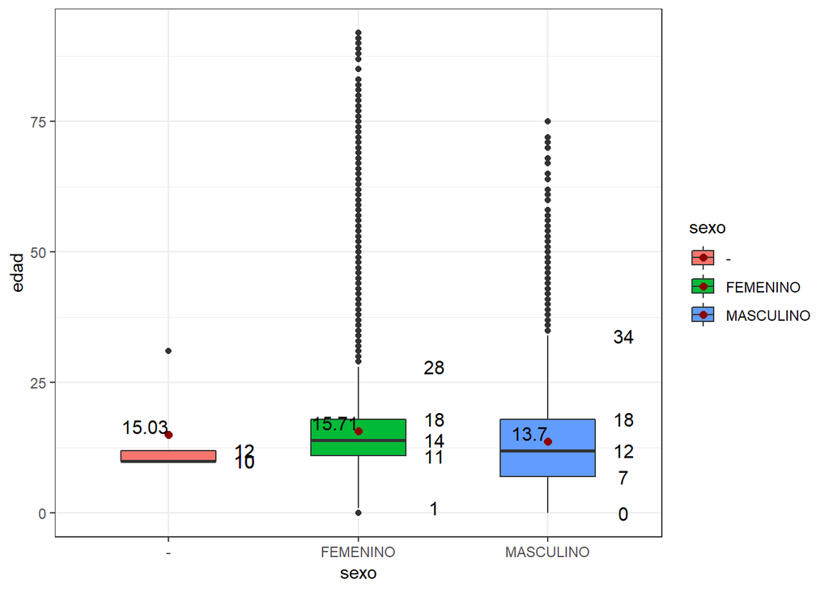

```r
meanFunction <- function(x){
  return(data.frame(y=round(mean(x),2),label=round(mean(x,na.rm=T),2)))
  }

g <- ggplot(data = d_sex3, aes(x = sexo, y = edad, fill=sexo)) + geom_boxplot(width = 0.5) +
  stat_summary(fun.y = mean, geom = "point",colour = "darkred", size=2) +
  stat_summary(fun.data = meanFunction, geom ="text", color = "black", size = 4, hjust = 1, vjust = -0.1) + theme_bw()

df <- ggplot_build(g)$data[[1]]


df <- ggplot_build(g)$data[[1]] %>%dplyr::select(ymin:ymax, x)%>% gather(type, value, - x) %>%arrange(x)

g + annotate("text", x = df$x + 0.4, y = df$value, label = df$value, size = 4)
```

Se crea un objeto que contiene la información de la base de datos original “d_sex”, y la población por departamento proyectada para el año 2017.

```r
d_sex3$codigo_dane<-as.character(d_sex3$codigo_dane)
dane$cdigo.dane<-as.character(dane$cdigo.dane)

colnames(d_sex3)[20]<-"dane"
colnames(dane)[6]<-"dane"

tab_municipios <- sqldf("SELECT *
              FROM d_sex3
             left join dane on d_sex3.dane=dane.dane")
View(tab_municipios)
```

Con el objeto tab_municipios se realizaran todas las Gráficas con granularidad municipio

## GRÁFICO DE MAPA

Granuralidad para los mapas sera departamento, y solamente revisarmenos el factor delitos/poblacion

Se cambia la variable departamento a caracter temporalmente para asignar codigo para poder trabajar con las BD dane y tab_map

```r
d_sex3$departamento<-as.character(d_sex3$departamento)

d_sex3<- d_sex3 %>%mutate(departamento = ifelse(departamento=="guajira" ,"la guajira", departamento))
tab_map<-as.data.frame(as.character(ohsCol2@data[["NAME_1"]]))
tab_map[ , "id"] <- c(0:31)
colnames(tab_map)[1]<-"departamento"
colnames(dane)[5]<-"habitantes"
tab_dsex<-as.data.frame(table(d_sex3$departamento))
tab_dsex[ , "id"] <- c(0:31)
tab_DANE<-as.data.frame(table(dane$DPNOM))
tab_DANE<- sqldf("SELECT tab_DANE.Var1,id
                 FROM tab_DANE
                 left join tab_dsex on tab_DANE.Var1=tab_dsex.Var1")
```

La sentencia variable[condición] <- expresión permite asignar los valores de la expresión si y solo si la condición es TRUE

```r
tab_DANE$id[4] <- 25
tab_DANE$id[6] <- 13
tab_DANE$id[31] <- 29

View(tab_DANE)
View(tab_map)
View(tab_dsex)
```

```r
d_sex3<- sqldf("SELECT *
              FROM d_sex3
              left join tab_dsex on d_sex3.departamento=tab_dsex.Var1")
View(d_sex3)
table(d_sex3$departamento == d_sex3$Var1)
```

```
##
##  TRUE
## 29191
```

```r
dane<- sqldf("SELECT *
             FROM dane
             left join tab_DANE on dane.DPNOM=tab_DANE.Var1")

View(dane)
```

# Cantidad de habitantes por departamento:

```r
habitantes<- sqldf("SELECT DPNOM,sum(dane.habitantes) as habitantes,id
              FROM dane
                   Group By DPNOM")

habitantes<- sqldf("SELECT DPNOM,sum(habitantes) as suma_habitantes,id
              FROM habitantes
                   Group By id")
View(habitantes)


habitantes<- sqldf("SELECT *
              FROM habitantes
                 left join tab_dsex on habitantes.id=tab_dsex.id")
```

# Cálculo de indice por departamento

A continuación se calcula el indice de Violencia Sexual por departamento de acuerdo a la frecuencia de estos delitos y a la población.

```r
habitantes$Indice <- habitantes$Freq/habitantes$suma_habitantes
```

```r
habitantes$Indice <- (habitantes$Indice)*10000
```

Usando estos elementos anteriormente calculados se crea el dataframe ohsColI2 uniendo los dataframes ohsCol2 (archivo .shp del mapa de colombia) y habitantes:

```r
ohsColI2 <- fortify(ohsCol2)
ohsColI2<- sqldf("SELECT *
              FROM ohsColI2
                 left join habitantes on ohsColI2.id=habitantes.id")
```

Con el dataframe resultante se procede a trazar el mapa de Colombia con sus divisiones departamentales, de la siguiente forma:

```r
mapColDep <- ggplot() +
  geom_polygon(data=ohsColI2, aes(x=long, y=lat, group = group, color = Var1, fill = Indice), colour ="black", size = 0.1) + scale_fill_continuous(low = "green" , high = "red") +
  labs(title = "Colombia", fill = "") + theme_bw() +
  labs(x="",y="",title="Indice Delitos Sexuales por Dpto por cada 10.000 habitantes ", size  = 5) +
  scale_x_continuous(limits=c(-80,-65))+
  scale_y_continuous(limits=c(-5,13))
```

Se realiza la misma acción con los mapas de San Andrés:

```r
mapColDepsan <- ggplot() +
  geom_polygon(data=ohsColI2, aes(x=long, y=lat, group = group,
                                  fill = Indice), colour ="black", size = 0.1) +
  labs(title = "San Andrés", fill = "") + theme_bw() +
  labs(x="",y="",title="San Andrés") + scale_fill_continuous(low = "green" , high = "red") +
  scale_x_continuous(limits=c(-81.739,-81.685))+
  scale_y_continuous(limits=c(12.46,12.62))
```

Y Providecia:

```r
mapColDepprov <- ggplot() +
  geom_polygon(data=ohsColI2, aes(x=long, y=lat, group = group,
                    fill = Indice), colour ="black", size = 0.1) +
  labs(title = "Providencia", fill = "") + theme_bw() +
  labs(x="",y="",title="Providencia") + scale_fill_continuous(low = "green" , high = "red") +
  scale_x_continuous(limits=c(-81.4,-81.345))+
  scale_y_continuous(limits=c(13.3,13.4))
```

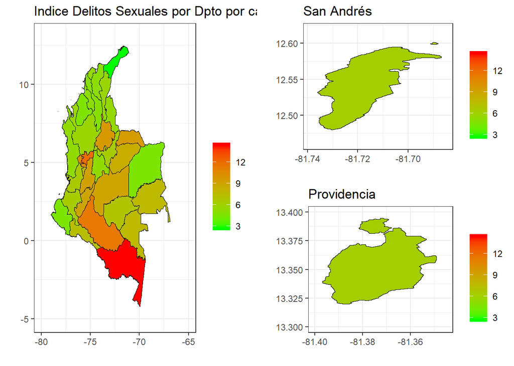

```r
grid.newpage()
pushViewport(viewport(layout = grid.layout(2, 2)))
vplayout <- function(x, y) viewport(layout.pos.row = x, layout.pos.col = y)
print(mapColDep, vp = vplayout(1:2, 1))  # key is to define vplayout
print(mapColDepsan, vp = vplayout(1, 2))
print(mapColDepprov, vp = vplayout(2, 2))
```

Gráfico Edad vs tipo de delito

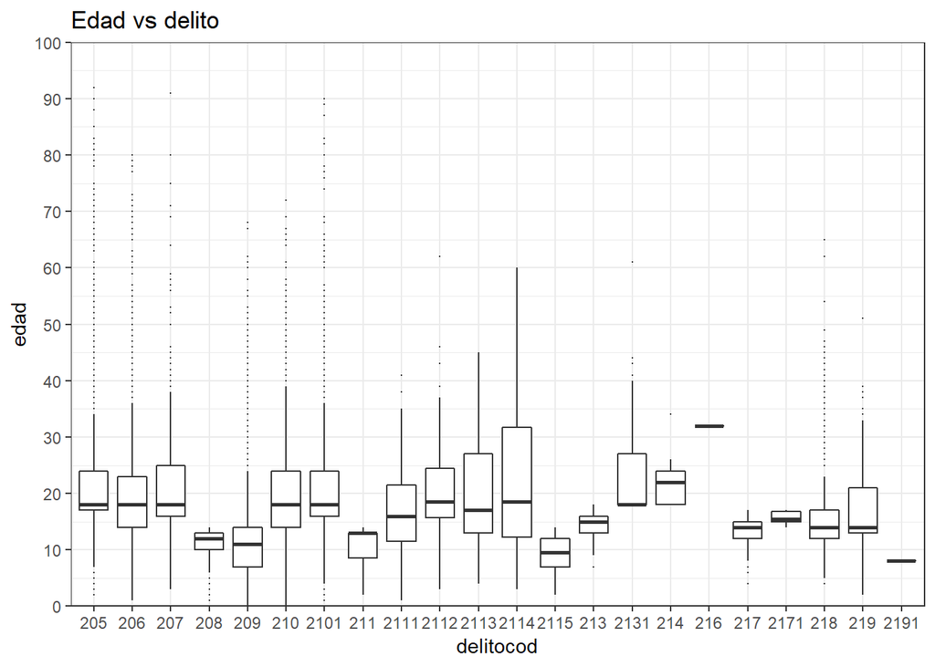

```r
t <- ggplot(d_sex3, aes(x = delitocod, y = edad)) + geom_boxplot(outlier.size = 0.1) +  theme(axis.text.x = element_text(size  = 10,angle = 45,hjust = 1,vjust = 1)) + labs(title = "Edad vs delito", fill = "") + scale_y_continuous(limits=c(0,100), breaks=seq(0,100,10), expand = c(0, 0)) + theme_bw()
t
```

# Inclusión de indice en la base d_sex3

A continuacion se ingresa la columna de indice en el dataframe d_sex3, tomándola como variable objetivo.

```r
tab_indice <- habitantes[,c(3,7)]
colnames(tab_indice) <- c("id","indice")

d_sex4 <- sqldf("SELECT *
              FROM d_sex3
              left join tab_indice on d_sex3.id=tab_indice.id")
```

Con este dataframe se procede a realizar análisis de variables asociadas con el indice de violencia por departamento hallado.

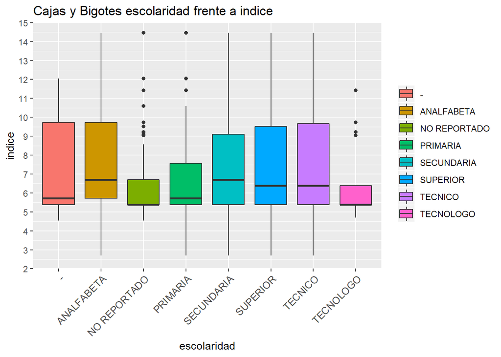

```r
ggplot(d_sex4, aes(x = escolaridad, y = indice)) + geom_boxplot(aes(fill = escolaridad)) +  theme(axis.text.x = element_text(size  = 10,angle = 45,hjust = 1,vjust = 1)) + labs(title = "Cajas y Bigotes escolaridad frente a indice", fill = "") + scale_y_continuous(limits=c(2,15), breaks=seq(2,15,1), expand = c(0, 0))
```

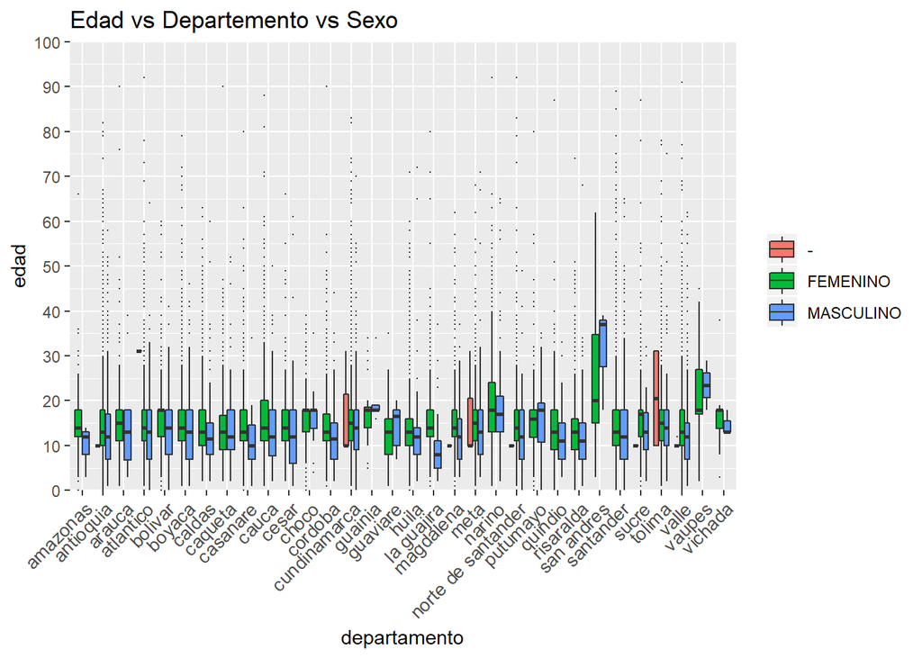

```r
d <- ggplot(d_sex4, aes(x = departamento, y = edad)) + geom_boxplot(aes(fill=sexo), outlier.size = 0.1) +  theme(axis.text.x = element_text(size  = 10,angle = 45,hjust = 1,vjust = 1)) + labs(title = "Edad vs Departemento vs Sexo", fill = "") + scale_y_continuous(limits=c(0,100), breaks=seq(0,100,10), expand = c(0, 0))
d
```

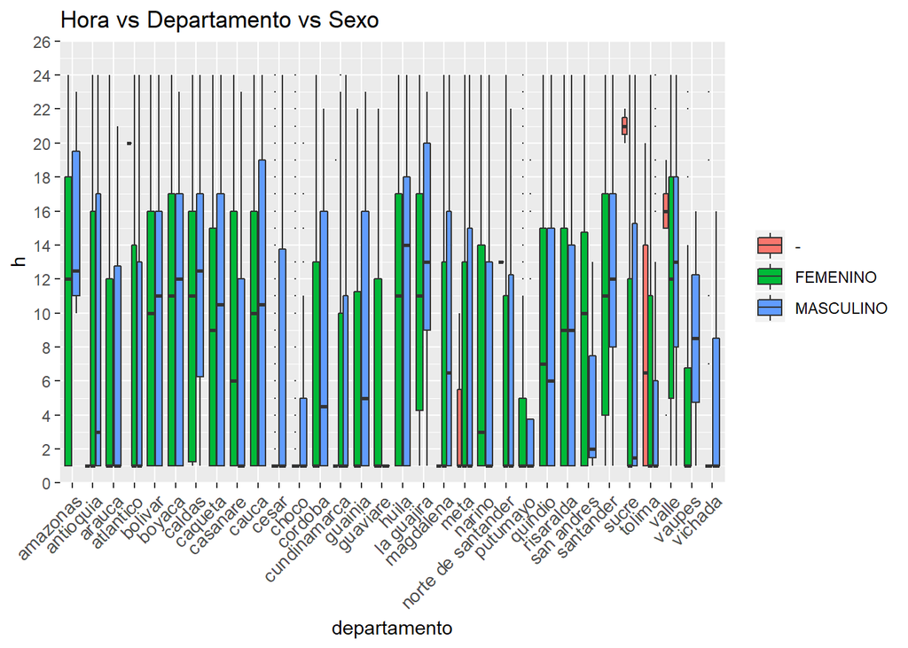

```r
d_sex4$h <- as.numeric(d_sex4$h)
h <- ggplot(d_sex4, aes(x = departamento, y = h)) + geom_boxplot(aes(fill=sexo), outlier.size = 0.1) +  theme(axis.text.x = element_text(size  = 10,angle = 45,hjust = 1,vjust = 1)) + labs(title = "Hora vs Departamento vs Sexo", fill = "") + scale_y_continuous(limits=c(0,26), breaks=seq(0,26,2), expand = c(0, 0))
h
```